# FrEDI Run Example

## About This Document

This file provides an example analysis using EPA’s Framework for Evaluating Damages and Impacts (FrEDI).

[figure not shown]

This example script:

1. Installs the FrEDI R package from GitHub
2. (optional) Imports FaIR and creates a custom temperature trajectory from SSP emission scenarios
3. Sets FrEDI input and run parameters, then runs FrEDI with default population, GDP assumptions, and custom temperature
4. Displays example plots of temperature trajectory and barchart of total annual U.S. climate-driven damages across FrEDI categories.

For more information about FrEDI, visit: https://www.epa.gov/cira/fredi

Code available at: https://github.com/USEPA/FrEDI

#### **Disclaimer: This code is meant to provide an illustrative example of how to set-up, run, and process a subset of FrEDI output. The results and code in this file should not be used for further analysis.**

#### About R Markdown

To run an individual chunk, hit the green ‘play’ button at the top right of each chunk.

# Processing Steps:

## Step 0. Install required R packages

Use this chunk to specify the required R libraries and set working directory (if needed)

## Step 1. Install FrEDI R package

Use this chunk to flag whether or not to install the FrEDI R package from EPA’s Enterprise GitHub (https://github.com/USEPA/FrEDI). Users can also specify the branch to be installed. The default is set to ‘main’

## Step 2. Use FaIR to create a temperature input for FrEDI (optional)

Use this chunk if you want to run a python instance of the FaIR simple climate model to generate a global temperature trajectory for FrEDI

FaIR is not an EPA product and is not endorsed by the Agency, please see the FaIR source code on GitHub for further details: https://github.com/OMS-NetZero/FAIR

To install FaIR, follow the install options at: https://github.com/OMS-NetZero/FAIR/blob/master/README.rst For example, if using Anaconda, open cmd.exe and run ‘pip install fair’. Then specify the correct path to your python instance (where fair is also installed) in the ‘setup’ chunk above

## Step 3. Run FrEDI

Use this chunk to specify the runtime parameters for FrEDI (including the specific user-defined temperature trajectory). Then run the main run_fredi() module.

## Step 4. Plot

The following chunks provide examples of figures generated from FaIR and FrEDI output

#### Define plotting parameters

Use this chunk to define sector categories and global plotting parameters

#### Plot Temperature Trajectory

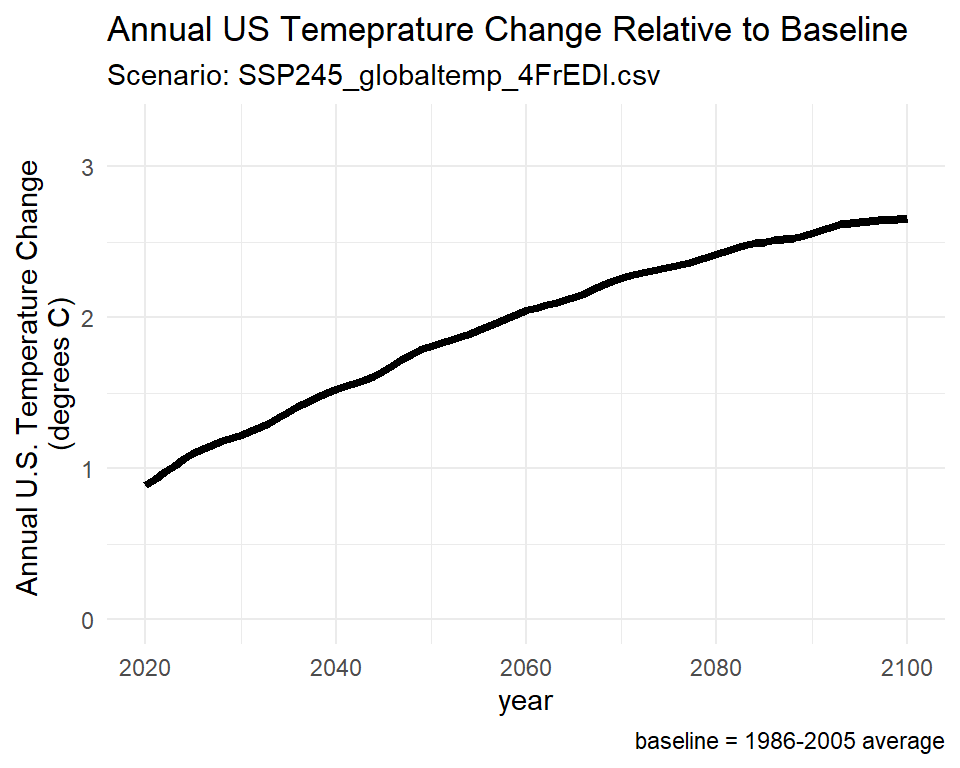

#### Plot National Results by Category

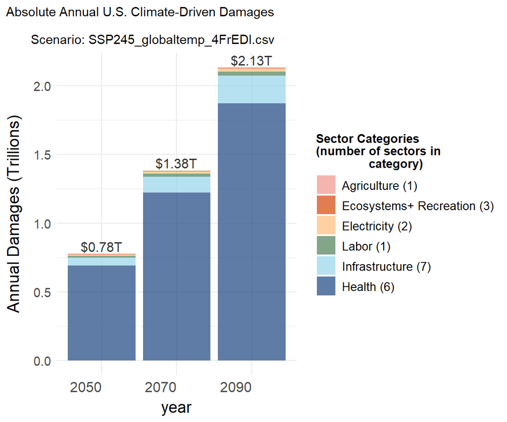

#### Table of National Sectoral Results (billions $2015USD)

National Total Damages by Sector, Scenario: SSP245_globaltemp_4FrEDI.csv

| Sector | Category | $Billon ($2015USD) | Region | Year |
| --- | --- | --- | --- | --- |
| ATS Extreme Temperature | Health (6) | 1700.000 | National Total | 2090 |
| Air Quality | Health (6) | 160.000 | National Total | 2090 |
| High Tide Flooding and Traffic | Infrastructure (7) | 130.000 | National Total | 2090 |
| Wildfire | Health (6) | 37.000 | National Total | 2090 |
| Labor | Labor (1) | 31.000 | National Total | 2090 |
| Wind Damage | Infrastructure (7) | 26.000 | National Total | 2090 |
| Rail | Infrastructure (7) | 17.000 | National Total | 2090 |
| Roads | Infrastructure (7) | 15.000 | National Total | 2090 |
| Southwest Dust | Health (6) | 13.000 | National Total | 2090 |
| Electricity Demand and Supply | Electricity (2) | 11.000 | National Total | 2090 |
| Electricity Transmission and Distribution | Electricity (2) | 10.000 | National Total | 2090 |
| Valley Fever | Health (6) | 10.000 | National Total | 2090 |
| Coastal Properties | Infrastructure (7) | 7.300 | National Total | 2090 |
| CIL Agriculture | Agriculture (1) | 4.400 | National Total | 2090 |
| Urban Drainage | Infrastructure (7) | 4.100 | National Total | 2090 |
| Water Quality | Ecosystems+ Recreation (3) | 2.200 | National Total | 2090 |
| Winter Recreation | Ecosystems+ Recreation (3) | 2.100 | National Total | 2090 |
| CIL Crime | Health (6) | 0.890 | National Total | 2090 |
| Inland Flooding | Infrastructure (7) | 0.710 | National Total | 2090 |
| Marine Fisheries | Ecosystems+ Recreation (3) | -0.057 | National Total | 2090 |

## Step 5. FrEDI SV Module

This chunk provides an example of running the FrEDI_SV() module to quantify differential impacts of climate change across different populations.

NOTE: ‘main’ run_fredi_sv does not currently run. (‘sv_template_update’ branch has the latest version)